# Analisi della similarità tra brani di spotify

21/01/2025

## Inroduzione e spiegazione ambito

Questa presentazione ha l’obiettivo di spiegare in breve l’ambito di studio, ovvero la top 2000 delle canzoni di spotify dal 2000 al 2020 e le analisi fatte sul grafo risultante dal calcolo della similarità tra brani.

- Il grafo rappresentativo è stato costruito con i nodi che rappresentano le canzoni e gli archi la similarità tra di esse.
- La similarità tra le canzoni è stata calcolata creando una matrice di n dimensioni (con n=7 per il numero di features che vengono assegnate da Spotify ad ogni brano) che rappresenta ogni nodo come un punto in uno spazio e gli assegna un collegamento se la vicinanza ad un altro nodo non supera una determinata soglia.

## Prima parte dell’analisi

La prima parte consiste in un analisi generale, per determinare dati come il diametro e la distanza media, per analizzare che tipo di grafico risulti dal grado di similarità calcolato.

```
## La distanza media è: 4.435601
```

```
##    Distanza Frequenza
## 2         1     43912
## 3         2    272110
## 4         3    585542
## 5         4    671700
## 6         5    510054
## 7         6    283318
## 8         7    135410
## 9         8     62058
## 10        9     29566
## 11       10     16644
## 12       11     12036
## 13       12      9250
## 14       13      6636
## 15       14      5908
## 16       15      6256
## 17       16      4976
## 18       17      2408
## 19       18       692
## 20       19       140
## 21       20        24
## 22       21         2
```

- Considerando che il range tipico delle distanze si trova tra 2 e 6 una distanza di 4.44 è medio-bassa e, pur essendoci cammini decisamente più lunghi, sono rari quelli di distanza 10+

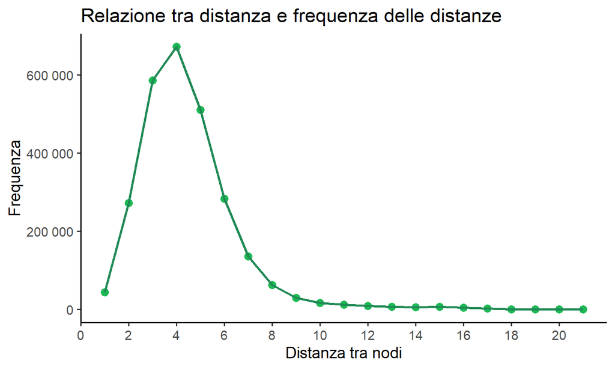

## Analisi generale /2

Calcoliamo anche il diametro:

```
## 21
```

Il risultato di 21, nonostante risulti abbastanza alto, confrontandolo con i dati precedenti suggerisce che i nodi siano abbastanza connessi tra loro con una minor percentuale di eccezioni che comprendono canzoni particolarmente diverse tra loro.

```
## Prima canzone: Day 'N' Nite (Nightmare)
```

```
## Ultima canzone: Get Busy
```

- Sia la canzone iniziale che finale hanno come genere pop o hip hop, complice anche il fatto che siano i generi più diffusi nel dataset: un primo indizio del fatto che forse la classificazione per genere non è indicativa della similarità tra brani.

## Analisi generale /3

Ho creato il grafico della distribuzione grado/frequenza:

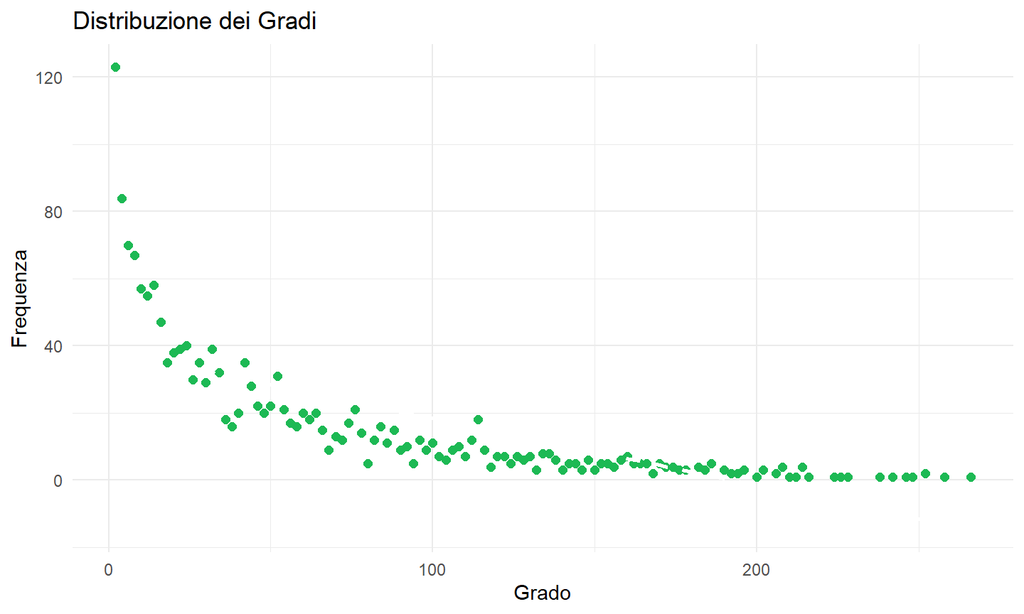

- Guardando il grafo è possibile notare un rapporto inversamente proporzionale tra grado e frequenza: all’aumentare del grado la frequenza dimiuisce sensibilmente; dimostrato anche dall’indice di assimmetria:

```
## Indice di assimmetria di grado: 1.433037
```

- La forma del grafico ricorda inoltre una coda lunga, tipica della power law; per verificare ho creato il grafico in scala logaritmica:

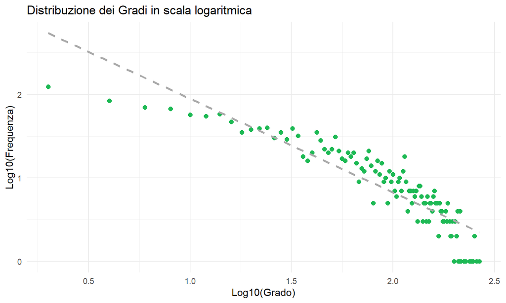

- La pendenza della retta è di -1.12: questo sarebbe anche l’eventuale esponente della power law.
- Nonostante questo valore si trovi solitamente tra -2 e -3 posso affermare che non segua le proprietà di una rete scala free classica ma che abbia comunque qualche caratteristica di una distribuzione power law (con crescita lenta).

## Trovare correlazioni

Visto che il grafo è stato creato tramite un treshold indicativo che detta il suo numero di connessioni potrebbe essere interessante cercare eventuali correlazioni tra grado di un nodo e gli attributi non legati al calcolo della similarità tra brani

[figure not shown]

## Rilevamento comunità

Sono state inoltre rilevate le comunità presenti nel grafo, eliminando però i nodi con un grado inferiore a 13 per migliorare la visibilità

```
## Numero di connessioni tra nodi della stessa comunità: 27590
```

```
## Numero di connessioni tra nodi di comunità diverse: 14200
```

- Anche diminuendo il grado minimo per essere inclusi nel calcolo il rapporto tra gli archi tende a rimanere 1/2.
- È giusto citare il fatto che va impostato un seed per il calcolo delle comunità in quanto l’algoritmo elabora i nodi in modo casuale e la scelta dei nodi iniziali può influenzare il risultato finale (questo non influisce comunque più di tanto sul rapporto)

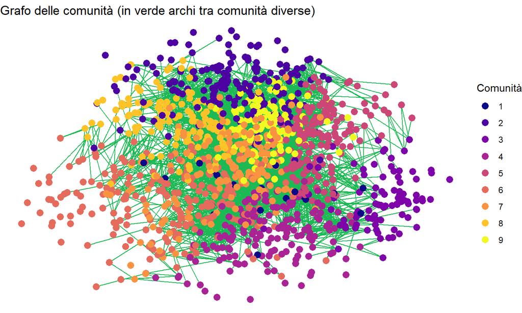

```
## Le comunità sono composte da questo numero di nodi:
```

```
## 20 180 88 160 159 215 169 139 116
```

## Rilevamento comunità \2

Notiamo che pur essendo le comunità molto più strettamente collegate hanno anche abbastanza ponti che le uniscono.

- Probabilmente ciò è dovuto al fatto che le canzoni appartenenti alla top 2000 sono molto simili: differiscono evidentemente nel calcolo (quanto basta da creare le comunità e trovando quindi maggior affinità tra loro) ma abbiamo un’altra conferma che la classificazione per genere evidentemente non è così indicativa.

## Rilevamento comunità \3

Per verificare se le comunità sono in qualche modo sovrapponibili alla divisione per generi ho creato una heatmap generi/comunità:

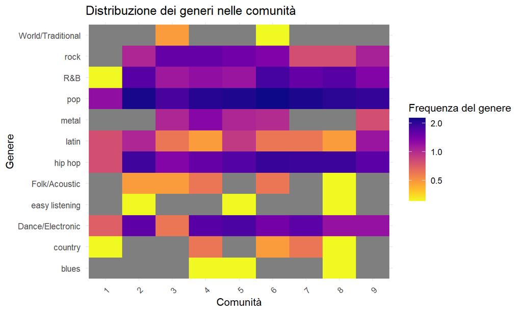

## Rilevamento comunità \4

- Guardando la heatmap non sembrano esserci divisioni marcate che indicano una prevalenza di un determinato genere in una specifica comunità; questo è dovuto, come detto prima, alla similarità tra le canzoni di successo ma anche all’assegnazione di più generi ad un singolo brano.
- Possiamo affermare che un calcolo delle comunità, se correttamente attuato, potrebbe essere utile a Spotify per scegliere quali canzoni consigliare seguendo un flusso sensato e passando da una tipologia all’altra in modo graduale (ad esempio, nodi con alta betweenness centrality sono utili per passare da tipo di musica ad un altro gradualmente)
- Infine è chiaro che la divisione per generi sia più utile agli utenti finali piuttosto che come strumento per il calcolo di similarità tra due brani.